# Tidy Tuesday 22/10/19

This is an attempt to see what I can produce from the tidytuesday dataset for 22/10/19.

The link is [here](https://github.com/rfordatascience/tidytuesday/tree/master/data/2019/2019-10-22)

```r
horror_movies <- readr::read_csv("https://raw.githubusercontent.com/rfordatascience/tidytuesday/master/data/2019/2019-10-22/horror_movies.csv")
```

Duration against time

```r
horror_movies %>%
  ggplot(aes(x = release_date, y= movie_run_time)) +
  geom_point()
```

[output not shown]

Further tidying needed

```r
glimpse(horror_movies)
```

[output not shown]

All are characters.

Date is of either one of two formats

- year alone (4 characters)
- day/month/year (can use `dmy`)

To start with let’s just extract the year component. Later (possibly) we could try to impute the dates for those records wehre only the year exists.

```r
horror_movies2 <-
  horror_movies %>%
    mutate(type = ifelse(
      nchar(release_date) == 4,
      "NUM",
      "DATE"
      )
    ) %>%
    mutate(
      date2 = ifelse(
        type == "NUM",
        paste0("15-6-", release_date),
        release_date
      )
    ) %>%
    mutate(
      release_date2 = lubridate::dmy(date2)
    )
```

```r
horror_movies2 %>%
  mutate(
    yr = lubridate::year(release_date2)
  ) %>%
  mutate(
    dur = stringr::str_extract(movie_run_time, "\\d+") %>% as.numeric
  ) %>%
  ggplot(aes(x = release_date2, y = dur)) +
  geom_point() +
  stat_smooth()
```

[output not shown]

My suspicion is that horror films are particularly short. Let’s try and extract those films which are horror.

Of course this is a stupid question to ask, as they’re all horror films. Instead the question could be reframed as:

- Are films that are just horrors shorter than films of multiple genres?

The number of genres can be determined by the number of “|” symbols in the string `genres`.

Let’s test this with some simple strings

```r
str_count("Horror | Sci-Fi", "\\|")
```

```
[1] 1
```

[output not shown]

So let’s go for a binary division: Is the duration of ‘pure horror’ films lower than of mixed genre?

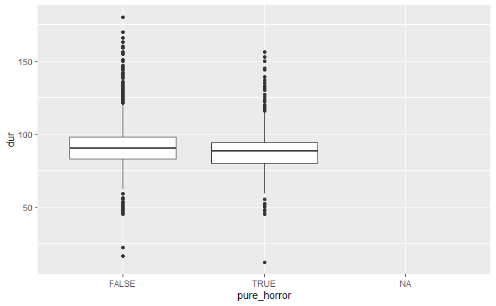

```r
horror_movies2 %>%
  mutate(
    num_additional_genres = map_int(genres, str_count, "\\|")
  ) %>%
  mutate(
    pure_horror = num_additional_genres == 0
  )  %>%
  mutate(
    dur = stringr::str_extract(movie_run_time, "\\d+") %>% as.numeric
  ) %>%
  ggplot(aes(x = pure_horror, y = dur)) +
    geom_boxplot()
```

Let’s test this

```r
horror_movies2 %>%
  mutate(
    num_additional_genres = map_int(genres, str_count, "\\|")
  ) %>%
  mutate(
    pure_horror = num_additional_genres == 0
  )  %>%
  mutate(
    dur = stringr::str_extract(movie_run_time, "\\d+") %>% as.numeric
  ) %>%
  lm(dur ~ pure_horror, .) %>%
  anova()
```

```
Analysis of Variance Table

Response: dur
              Df Sum Sq Mean Sq F value    Pr(>F)
pure_horror    1   8125  8124.7  36.561 1.677e-09 ***
Residuals   2782 618218   222.2
---
Signif. codes:  0 ‘***’ 0.001 ‘**’ 0.01 ‘*’ 0.05 ‘.’ 0.1 ‘ ’ 1
```

So a statistically significant reduction

```r
horror_movies2 %>%
  mutate(
    num_additional_genres = map_int(genres, str_count, "\\|")
  ) %>%
  mutate(
    pure_horror = num_additional_genres == 0
  )  %>%
  mutate(
    dur = stringr::str_extract(movie_run_time, "\\d+") %>% as.numeric
  ) %>%
  lm(dur ~ pure_horror, .) %>%
  broom::tidy()
```

| term | estimate | std.error | statistic | p.value |
| --- | --- | --- | --- | --- |
| (Intercept) | 91.976710 | 0.3318423 | 277.169904 | 0.000000e+00 |
| pure_horrorTRUE | -3.825274 | 0.6326333 | -6.046589 | 1.677325e-09 |

So pure horror films are about 4 minutes shorer on average than mixed genre films, and horror films are around 92 minutes (i.e. shorter than most films these days seem to be).

Of films that contain only one additional genre, what’s the mean length of each genre?

```r
horror_movies2 %>%
  mutate(num_additional_genres = map_int(genres, str_count, "\\|")) %>%
  filter(num_additional_genres == 1) %>%
  mutate(other_genre = genres %>%
            str_remove_all("\\|") %>%
            str_remove_all("[Hh]orror") %>%
            str_trim()) %>%
  count(other_genre, sort = TRUE) %>%
  mutate(total_n = cumsum(n)) %>%
  mutate(prop_n = (n / sum(n)) %>% round(2))
```

| other_genre | n | total_n | prop_n |
| --- | --- | --- | --- |
| Thriller | 474 | 474 | 0.48 |
| Comedy | 245 | 719 | 0.25 |
| Drama | 72 | 791 | 0.07 |
| Mystery | 47 | 838 | 0.05 |
| Action | 44 | 882 | 0.04 |
| Sci-Fi | 42 | 924 | 0.04 |
| Fantasy | 25 | 949 | 0.03 |
| Animation | 6 | 955 | 0.01 |
| Crime | 6 | 961 | 0.01 |
| Romance | 6 | 967 | 0.01 |

[output cut: 6 more lines]

So the most common genres are Thrillers, Comedies, Dramas, and Mysteries. Around a half are also thrillers, and a quarter are comedies

Let’s now compare the following for duration

- Pure horrors
- Horror Thrillers
- Horror Comedies

```r
horror_movies2 %>%
  mutate(num_additional_genres = map_int(genres, str_count, "\\|")) %>%
  mutate(other_genre = genres %>%
            str_remove_all("\\|") %>%
            str_remove_all("[Hh]orror") %>%
            str_trim()) %>%
  mutate(
    is_thriller = map_lgl(other_genre, str_detect, "[Tt]hriller"),
    is_comedy   = map_lgl(other_genre, str_detect, "[Cc]omedy"),
    is_pure     = num_additional_genres == 0
  ) %>%
  mutate(
    dur = stringr::str_extract(movie_run_time, "\\d+") %>% as.numeric
  ) %>%
  lm(dur ~ is_thriller + is_comedy, .) %>%
  broom::tidy()
```

| term | estimate | std.error | statistic | p.value |
| --- | --- | --- | --- | --- |
| (Intercept) | 89.881307 | 0.4260245 | 210.976844 | 0.000000000 |
| is_thrillerTRUE | 1.439548 | 0.5866766 | 2.453733 | 0.014199113 |
| is_comedyTRUE | 2.445371 | 0.7888218 | 3.100030 | 0.001954383 |

```r
NA
```

So, thrillers are slightly longer, and comedies longer still.

What about the relationship betwen these three main types and budget?

Let’s just look at those with budgets reported in dollars

Changed my mind, looking at rating instead

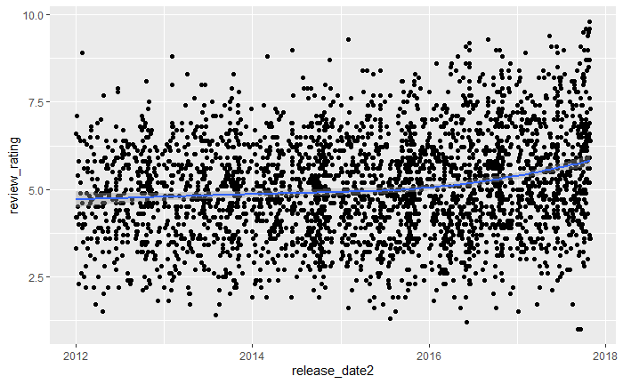

```r
horror_movies2 %>%
  ggplot(aes(release_date2, review_rating)) +
  geom_point() +
  stat_smooth()
```

There’s possibly been an upshift in rating in the last couple of years

Let’s colour the points by genre

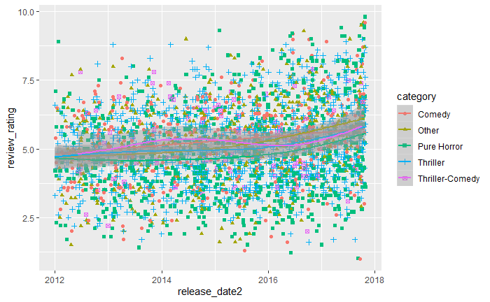

```r
horror_movies2 %>%
  mutate(num_additional_genres = map_int(genres, str_count, "\\|")) %>%
  mutate(other_genre = genres %>%
            str_remove_all("\\|") %>%
            str_remove_all("[Hh]orror") %>%
            str_trim()) %>%
  mutate(
    is_thriller = map_lgl(other_genre, str_detect, "[Tt]hriller"),
    is_comedy   = map_lgl(other_genre, str_detect, "[Cc]omedy"),
    is_pure     = num_additional_genres == 0
  ) %>%
  mutate(
    category = case_when(
      is_pure                  ~  "Pure Horror",
      is_thriller & !is_comedy ~  "Thriller",
      !is_thriller & is_comedy ~  "Comedy",
      is_thriller & is_comedy  ~  "Thriller-Comedy",
      TRUE                     ~  "Other"
    )
  ) %>%
  ggplot(aes(release_date2, review_rating, shape = category, colour = category)) +
    geom_point() +
    stat_smooth()
```

```r
NA
```

There’s no clear distinction between these categories as far as rating’s considered either.